# Science 10 Inquiry Projects

Language / 语言

## Introduction

Below you find a list of project ideas. Review the topics and select the inquiry questions that interest you the most. Our goal is to offer a range of opportunities that allow you to choose the one that interests you most. So you can pursue this interest. The common thread throughout all these projects is that they provide you with the opportunity to gain a deeper understanding of how this topic relates to the real world. The projects typically involve research, simulations, or hands-on activities, and often require presentations or reports that adhere to specific formatting guidelines. If you don't see a topic that resonates with you, feel free to suggest a related topic to your teacher. Also, be aware of notes and requirements for specific projects. Be creative and inquisitive as you complete your chosen project.

## Instructions

1. You have four projects, one from each unit, to complete.
2. Select a project from a unit from the list below.
3. Each project should be typed.
4. Each project should be contained **in a single** file (typically a Word document), where all relevant data, images, scans, and other materials are included. It should be named and completed.
   1. The file size should not exceed the recommended limit of approximately 1 MB per page. For a document of 10 pages, aiming for a total size of around 10 MB would be ideal. To assist you in this, may I suggest trying Adobe's online PDF compression tool at https://www.adobe.com/ca/  
      acrobat/online/compress-pdf.htm.
5. Check with your teacher if you wish to deviate from the project list.
6. Your project should include an introduction and reflection.
7. Presentation does count. Your final paper should be in APA format. [Click here](https://drive.google.com/file/d/1y8DqN2rxs0VUllk5kDZfxPpkCKlbIORJ/view?usp=sharing) for an example of a lab report in APA format. [Click here](https://drive.google.com/file/d/1G3pW5zDVXnpzotbqSe87o2exjz6HXwwn/view?usp=sharing) for an example of a paper in APA format. Make sure:
   1. See this link for a template for your final project  
      https://docs.google.com/document/d/1BNoiax7iF3B1Bp754N94g-R-j22OUm_uBqvd2k2KYx4/edit?usp=sharing
   2. Title Page
   3. Margins: Ensure 2.54 cm margins on all sides of the page.
   4. Spacing: The entire document should be double-spaced, including the title page, abstract, block quotes, and the references list. There should be no extra spacing between paragraphs.
   5. Introduction or Abstract
   6. Page #s
   7. In-text citations
   8. The Headings are properly set up
   9. Tables, charts and figures are properly set up
   10. Indentations for the first line of each paragraph
   11. Reflection
   12. References - It must start on a new page.
8. Your project should be typed and include a rubric. The **rubric** should have included the BC Provincial Proficiency Scale (Emerging, Developing, Proficient, and Extending).

| **The Provincial Proficiency Scale** | **Emerging** | **Developing** | **Proficient** | **Extending** |
| --- | --- | --- | --- | --- |
|  | The student demonstrates an initial understanding of the concepts and competencies relevant to the expected learning. | The student demonstrates a partial understanding of the concepts and competencies relevant to the expected learning. | The student demonstrates a complete understanding of the concepts and competencies relevant to the expected learning. | The student demonstrates a sophisticated understanding of the concepts and competencies relevant to the expected learning. |

“**Emerging**” indicates that a student is just beginning to demonstrate learning in relation to the learning standards, but is not yet doing so consistently. Emerging isn’t failing.  
“**Developing**” indicates that a student is demonstrating learning in relation to the learning standards with growing consistency. The student is showing initial understanding but is still in the process of developing their competency in relation to the learning standards.  
“**Proficient**” is the goal for students. A student is Proficient when they demonstrate the expected learning in relation to the learning standards.

“**Extending**” is not synonymous with perfection. Extending means a student is demonstrating learning in relation to the learning standards with increasing depth and complexity.

There should be a description for each of these components. Create a rubric in table format and complete a self-evaluation. Make sure to include at least one criterion for “Presentation does count.”

| Criteria | Emerging | Developing | Proficient | Extending |
| --- | --- | --- | --- | --- |

9. Additionally, **references** should be provided in APA format.
- The sources should be in APA format. For help with APA formatting, go to the Virtual Learning Commons (in Brightspace) and select Citations under Content > Information Centre
  - Or use https://www.citationmachine.net/apa
- To create an APA citation for a website, follow these steps:
1. **Author**: Start with the author's last name, followed by their initials. If no author is available, begin with the title.
2. **Date**: Include the publication date in parentheses (year, month day). If no date is available, use (n.d.).
3. **Title**: Write the title of the webpage in italics. Only the first word of the title and subtitle, as well as proper nouns, should be capitalized.
4. **Website Name**: After the title, add the name of the website in plain text.
5. **URL**: End with the full URL of the webpage.

> **Example**:

> Smith, J. (2023, October 15). *Understanding climate change*. Environmental News. https://www.environmentalnews.com/  
> climate-change

This format ensures clarity and consistency in your citations.

This document was last updated on July 29, 2025.

## Biology Projects

These projects focus on topics such as genetics (chromosomes, DNA, gene mutations, inherited traits, reproduction, and natural selection) and data literacy (evaluating the usefulness of sources, formulating powerful questions, distinguishing observations from inferences, and effective graphical representation).

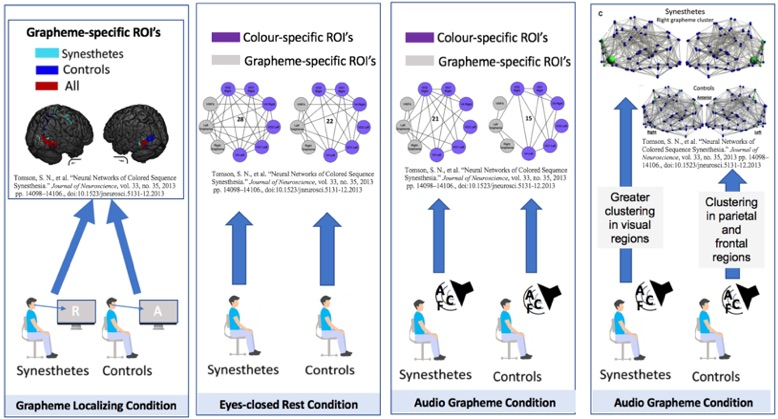

[**What makes an effective graphical representation of information?**](https://drive.google.com/file/d/1JpBKYhy4v3btJ29C3u56OntAuwt_SsV-/view?usp=sharing)

The project aims to teach users about graphical abstracts and how to create effective ones. It emphasizes the importance of effective communication of scientific information, especially through graphical abstracts, to ensure accessibility and understanding for a wide audience.

Topics: TC2, critical thinking, science communication, visuals, Graphs, tables, graphical abstracts

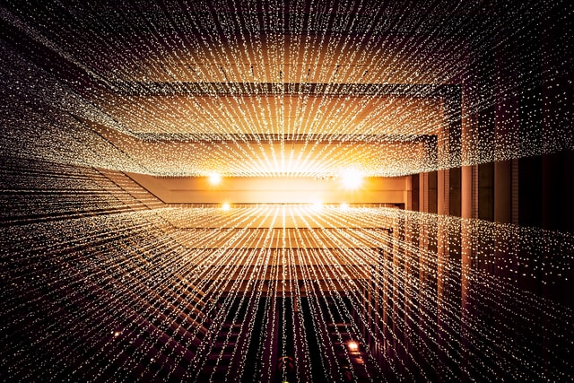

[**What makes a quality observation, inference, and conclusion?**](https://drive.google.com/file/d/1tUPmB_GoMn1YEqBVa0kslSiPgrPdWTUE/view?usp=sharing)

This project aims to help the student rate the quality of observations and inferences to develop sound conclusions.

Topics: TC2, critical thinking, observation, inference, conclusion

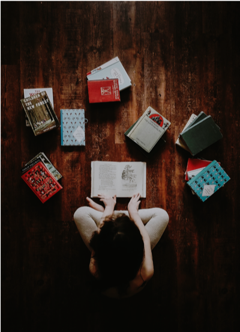

[**How can you be sure the sources you are using are reliable?**](https://drive.google.com/file/d/1EDyOTybZcQXPHcbpNzMLVZEx2H2XofN4/view?usp=sharing)

This inquiry focuses on helping users determine the reliability of information sources, especially in the context of research projects where conflicting views may arise.

Topics: critical thinking, lateral reading, tc2

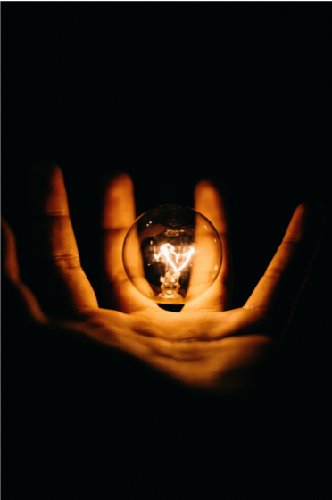

**[What makes a powerful question?](https://drive.google.com/file/d/1rxtvY80HsEaULf5ugsgW-3cDxOnd3NtP/view?usp=sharing)**

This project focuses on what makes a powerful question. It aims to help improve the ability to ask powerful questions in various situations, especially regarding information accuracy and source trustworthiness in news and social media.

Topics: critical thinking, tc2, accurate information, accurate sources

[figure not shown]

**[How can you determine if sources are useful?](https://drive.google.com/file/d/1itNVSMMpyPjuoK6ARI8tvWeT6-FtOIQ0/view?usp=sharing)**  
This inquiry project designed to teach a strategy for determining the usefulness of sources for research. The goal is to learn how to determine the usefulness of sources.

Topics: critical thinking, tc2, accurate sources, reliable, research, data literacy

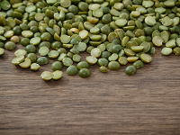

[**DNA is the “master set of instructions” of living cells. Can we extract the DNA from things, once living, that are in my kitchen?**](https://drive.google.com/file/d/1hXkxUboqJ6cAhQ-3tO-FvRPzjS8ck_mY/view?usp=sharing)

This inquiry project focused on extracting DNA from once-living things found in a kitchen, specifically dried split peas. The goal is to learn about DNA and its extraction by performing a kitchen lab.

Topics: extraction, DNA

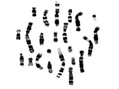

[**The fun of matching up chromosomes, what would an organized profile of a person’s chromosomes look like?**](https://drive.google.com/file/d/1HXVAS4z0M12o3MQvtsFDlY7vpPHLa6Lz/view?usp=sharing)

This project about chromosomes and karyotypes. The project aims to teach users about karyotypes by having them create a virtual karyotype by matching 22 chromosomes based on size, banding patterns, and centromere positions.

Topics: karyotype, chromosomes

[figure not shown]

[**Consider just one of the many genetic conditions. What is the nature of the changes in the genome, and why does it occur?**](https://drive.google.com/file/d/1FBsgrZStNUQ7zbUm83M2AiBW787o3cxZ/view?usp=sharing)

This biology project is on genetic conditions. The project asks students to research a chosen genetic condition and create an electronic presentation about it.

Topics: changes, genetic condition

[figure not shown]

[**What is the story behind the Spirit Bear?**](https://drive.google.com/file/d/1G_pcMRHDxaCxj3WRtVNAMrnYbns-povi/view?usp=sharing)

You are to create an electronic storybook about the Spirit Bear. The storybook should teach children about the Kitasoo Xai'xais people's legend of the Spirit Bear and its genetics.

Topics: genetics, Spirit Bear

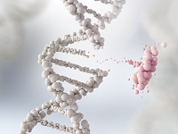

[**Our genes are determined by DNA sequences. How do gene mutations affect these DNA sequences?**](https://drive.google.com/file/d/1eNjcv8tUxp2X119LpkRhjTce8QAW8Tid/view?usp=sharing)

This project focuses on how gene mutations affect DNA sequences. The objective is to understand how gene mutations (deletions, additions, substitutions) occur and their impact on DNA sequences and the production of amino acids.

Topics: DNA sequences, genes, gene mutations

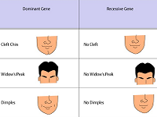

[**How do my genetic traits compare to those of others?**](https://docs.google.com/document/d/1WtnLbQur4Wf95RcsqWyetMjyt9nEehWAa5puxz9tpcc/edit?usp=sharing)

The goal of this project is for you to familiarize yourself with genetic traits, both your own and those of others.

Topics: dominant, genetic traits, recessive, traits

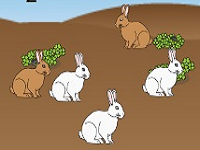

[**What is the secret to bunny rabbit survival?**](https://drive.google.com/file/d/1QNHTHvM0YaRA2EMYtunTF1XKDcUrHDAx/view?usp=sharing)

The main goal of this project is for students to understand how different traits and environmental factors—such as predators, limited food, and opportunities for camouflage—affect a species' population over time.

Topics: natural selection

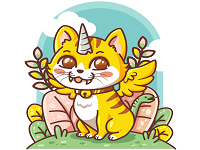

[**When two organisms unite, what offspring can be created?**](https://drive.google.com/file/d/10axo6DDPrjGSKcVfIWew_A0Ce6BpbpFm/view?usp=sharing)

The inquiry question for this project is: "When two organisms unite, what offspring can be created?" The project focuses on understanding how offspring inherit characteristics from their parents through dominant and recessive genes.

Topics: Offspring, Sexual Reproduction, Traits

## Earth Science Projects

These projects delve into Earth Science topics related to space, such as designing a periodic table of the solar system, exploring characteristics of stars using a Hertzsprung-Russell diagram, and analyzing the effects of extraterrestrial impacts.

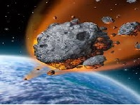

[**Aliens? What happens when they arrive? How much damage will an extra-terrestrial cause?**](https://drive.google.com/file/d/1Ur1EdR79lQVWKmqzOw6uTCg6F7je4Prj/view?usp=sharing)

Topics: damage, density, impactor, asteroids

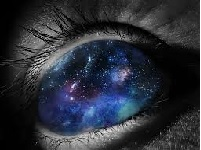

[**“How I wonder how old you are?”**](https://drive.google.com/file/d/1tgby2e7unNojExhNl6V5EaWR-W6CvFm8/view?usp=sharing)

Topics: black hole, Hertzsprung-Russell diagram, main sequence, red giants, temperature, luminosity

[figure not shown]

[**Are there common traits among the planets in our Solar System?**](https://drive.google.com/file/d/1ZrrMDwuSLWjSnVO0rNQSoK1seXUs0ZIW/view?usp=sharing)

There is a dead link in this project. Pick another project.

The project asks students to design a "Periodic Table of the Solar System" to explore common traits and patterns among the planets.

Topics: Groups, Planets, Properties

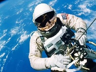

[**Do you have “The Right Stuff”? Are you a “Hidden Figure”?**](https://drive.google.com/file/d/1VBu-lgE7j4-C8JVqqPFGnkp6Fcp72uSX/view?usp=sharing)

Topics: Canadian, Astronaut, traits

## Chemistry Projects

These projects cover chemical reactions, including energy changes (exothermic and endothermic reactions) and balancing chemical equations, as well as an investigation into pH using household products.

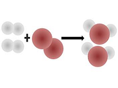

**[Given that you can’t get something from nothing, how do chemical reactions work?](https://drive.google.com/file/d/1a7EFBXVSHdwd2WUZEUblJXz9aktas43-/view?usp=sharing)**  
This project aims to help the user understand the Law of Conservation of Mass by working through a PhET simulation.

Topics: law of conservation of mass

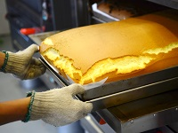

**[We need heat to bake a cake while hand-warmer packets give off heat. How is heat energy involved in chemical reactions?](https://drive.google.com/file/d/1onHpuMYxBHee29j565Z4Yf70gGkwasUX/view?usp=sharing)**  
This project discusses how heat is involved in chemical reactions, using examples like baking a cake (requires heat) and hand-warmer packets (give off heat).

Topics: Exothermic, Endothermic

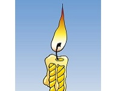

**[Chemical reactions show how matter changes. What chemical reaction is important to you and how is it important?](https://drive.google.com/file/d/14Rp3HN6LNqBoIEk_XGHD7BKbkNJww3h0/view?usp=sharing)**  
The project emphasizes that chemists study how matter changes and that understanding these changes is crucial for creating desired products and minimizing undesirable ones (like rust). Students are asked to consider a chemical reaction that has personal, local, or global importance.

Topics: chemical reactions

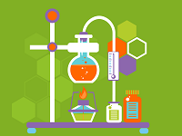

**[There are many different types of chemical reactions. How are they similar and different?](https://drive.google.com/file/d/1lttTQkgQwOXKA-TX6whYFGSsdChHdqhT/view?usp=sharing)**  
The project requires you to create a concept map using presentation software (Prezi, Google Slides, or PowerPoint) to compare and contrast six main types of chemical reactions covered in the unit. The goal of this project is to compare and contrast the six types of chemical reactions introduced in this chemistry unit.

Topics: chemical reactions

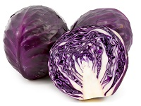

**[Can I estimate the pH of different household products using just what I have in my kitchen?](https://drive.google.com/file/d/1XkMc84l6uxuImD2ijK0eeAJSIk0E5hfV/view?usp=sharing)**  
The main goal of this project is for students to investigate acids, bases, and pH by creating their own pH indicator solution using red cabbage juice.

Topics: indicator, red cabbage, pH

## Physics Projects

These projects explore concepts of energy, including the conservation of energy in a simulated skate park, determining the power of a simple toy, and measuring calories in food through calorimetry.

[figure not shown]

**[What is “power”? Can you design an experiment that will allow you to determine the power of a simple toy? Can you improve the toy to make it more “powerful”?](https://drive.google.com/file/d/1OmMmKdOok5RpntBk6_elXaDi5bzwzEGW/view?usp=sharing)**  
This project asks students to design an experiment to determine the "power" of a simple toy, and then suggest ways to improve the toy to make it more powerful. It defines power as the rate at which energy is transformed, giving the formula P = ΔE/t = W/t, or P = Fv for objects moving at a constant speed.

Topics: efficiency, energy, power

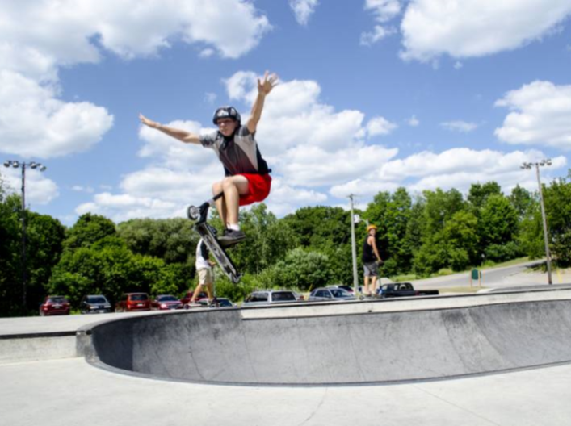

**[How "efficient" can you design a SkatePark track? Are some tracks more efficient than others? What energy transformations are involved?](https://drive.google.com/file/d/1UFiBOJ6B0dO96UxLwxLXMRlQHO8QWF9E/view?usp=sharing)**  
The project aims to demonstrate the conservation of energy, specifically the conversion between gravitational potential energy, work, and kinetic energy, while acknowledging the real-world impact of friction.

Students will use the "PHET Sim: Energy Skate Park: Basics" online simulation to complete the project. Key formulas provided are KE = ½mv², PE = mgh, and W = ΔE.

Topics: kinetic, potential, energy

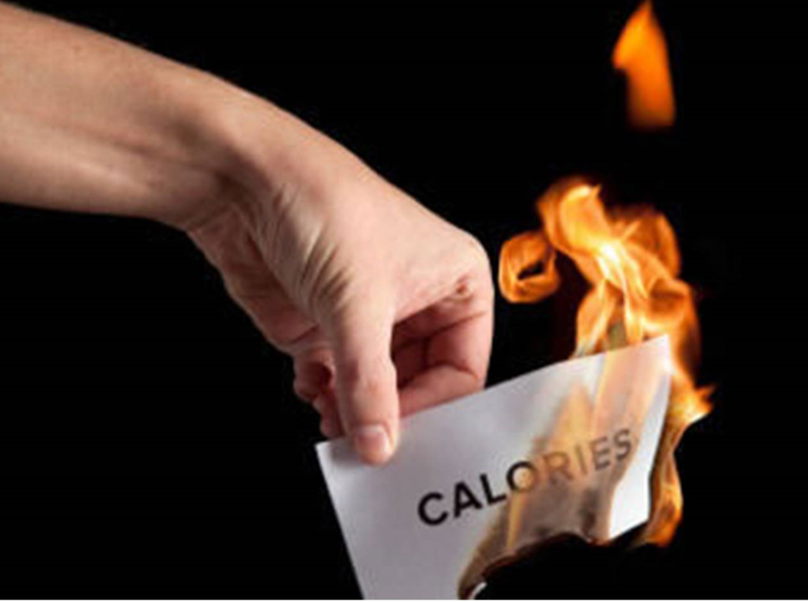

**[What is a "calorie" and how does it relate to energy? How can we determine how many calories a given food sample provides?](https://drive.google.com/file/d/12QMwsog1-56t1Du9NBfYNkuTE0ev3v-A/view?usp=sharing)**  
The core inquiry question is to understand what a "calorie" is, its relation to energy, and how to determine the caloric content of a food sample by burning it.

Topics: energy, heat, calorie